# ** DATA ANALYSIS PYTHON PROJECTS - BINKIT ANALYSIS**

**Sebastian Ortuno Barrero.**

##### This project uses python to perform analysis on data set regarding different Business requirements from the company BlinkIT.

#### **Business Requirements**

#### **1. Import Data and read the data**

#### **2. Explore the data***

#### **3. Data Cleaning**

##### 4.3 Averagee Sales.

##### 4.4 Number of Items sold.

##### 4.5 Average Ratings.

##### 4.6 Display the outputs.

#### **5. Chart Requirements**

##### 5.1 Total Sales by fat content

##### 5.2 Total sales by Item Type

##### 5.3 Fat Content by Outlet for Total Sales

##### 5.4 Total Sales by Outlet Establishment

##### 5.5 Sales by Outlet Establishment

##### 5.6 Sales by Outlet Location

#### **1. Import Data and read the data**

```python
import pandas as pd
import numpy as np
import matplotlib.pyplot as plt
import seaborn as sns
```

```python
df=pd.read_csv(r'/Users/sebastian/Downloads/BlinkIT Grocery Data.csv')
```

#### **2. Explore the data**

With all the necessary libraries imported and the data successfully loaded, the next step in our portfolio project is to explore the dataset. Through data exploration, we aim to understand the structure and format of the data, identify any patterns or anomalies, and determine the necessary cleaning steps required before proceeding with the analysis.

#### 2.1 **Glimpse of data:**

The preview above offers a brief look at the structure and content from our fist 20 observations.

```python
df.head(20)
```

|  | Item Fat Content | Item Identifier | Item Type | Outlet Establishment Year | Outlet Identifier | Outlet Location Type | Outlet Size | Outlet Type | Item Visibility | Item Weight | Sales | Rating |
| --- | --- | --- | --- | --- | --- | --- | --- | --- | --- | --- | --- | --- |
| 0 | Regular | FDX32 | Fruits and Vegetables | 2012 | OUT049 | Tier 1 | Medium | Supermarket Type1 | 0.100014 | 15.10 | 145.4786 | 5.0 |
| 1 | Low Fat | NCB42 | Health and Hygiene | 2022 | OUT018 | Tier 3 | Medium | Supermarket Type2 | 0.008596 | 11.80 | 115.3492 | 5.0 |
| 2 | Regular | FDR28 | Frozen Foods | 2016 | OUT046 | Tier 1 | Small | Supermarket Type1 | 0.025896 | 13.85 | 165.0210 | 5.0 |
| 3 | Regular | FDL50 | Canned | 2014 | OUT013 | Tier 3 | High | Supermarket Type1 | 0.042278 | 12.15 | 126.5046 | 5.0 |
| 4 | Low Fat | DRI25 | Soft Drinks | 2015 | OUT045 | Tier 2 | Small | Supermarket Type1 | 0.033970 | 19.60 | 55.1614 | 5.0 |
| 5 | low fat | FDS52 | Frozen Foods | 2020 | OUT017 | Tier 2 | Small | Supermarket Type1 | 0.005505 | 8.89 | 102.4016 | 5.0 |
| 6 | Low Fat | NCU05 | Health and Hygiene | 2011 | OUT010 | Tier 3 | Small | Grocery Store | 0.098312 | 11.80 | 81.4618 | 5.0 |
| 7 | Low Fat | NCD30 | Household | 2015 | OUT045 | Tier 2 | Small | Supermarket Type1 | 0.026904 | 19.70 | 96.0726 | 5.0 |
| 8 | Low Fat | FDW20 | Fruits and Vegetables | 2014 | OUT013 | Tier 3 | High | Supermarket Type1 | 0.024129 | 20.75 | 124.1730 | 5.0 |
| 9 | Low Fat | FDX25 | Canned | 2018 | OUT027 | Tier 3 | Medium | Supermarket Type3 | 0.101562 | NaN | 181.9292 | 5.0 |
| 10 | LF | FDX21 | Snack Foods | 2018 | OUT027 | Tier 3 | Medium | Supermarket Type3 | 0.084555 | NaN | 109.8912 | 5.0 |
| 11 | Low Fat | NCU41 | Health and Hygiene | 2017 | OUT035 | Tier 2 | Small | Supermarket Type1 | 0.052045 | 18.85 | 192.1846 | 5.0 |
| 12 | Low Fat | FDL20 | Fruits and Vegetables | 2022 | OUT018 | Tier 3 | Medium | Supermarket Type2 | 0.128938 | 17.10 | 112.3886 | 5.0 |
| 13 | Low Fat | NCR54 | Household | 2014 | OUT013 | Tier 3 | High | Supermarket Type1 | 0.090487 | 16.35 | 195.2110 | 5.0 |
| 14 | Low Fat | FDH19 | Meat | 2018 | OUT027 | Tier 3 | Medium | Supermarket Type3 | 0.032928 | NaN | 173.1738 | 5.0 |
| 15 | Regular | FDB57 | Fruits and Vegetables | 2017 | OUT035 | Tier 2 | Small | Supermarket Type1 | 0.018802 | 20.25 | 222.1772 | 5.0 |
| 16 | Low Fat | FDO23 | Breads | 2022 | OUT018 | Tier 3 | Medium | Supermarket Type2 | 0.147024 | 17.85 | 93.7436 | 5.0 |
| 17 | Low Fat | NCB07 | Household | 2012 | OUT049 | Tier 1 | Medium | Supermarket Type1 | 0.077628 | 19.20 | 197.6110 | 5.0 |
| 18 | Low Fat | FDJ56 | Fruits and Vegetables | 2018 | OUT027 | Tier 3 | Medium | Supermarket Type3 | 0.182515 | NaN | 98.7700 | 5.0 |
| 19 | Low Fat | DRN47 | Hard Drinks | 2022 | OUT018 | Tier 3 | Medium | Supermarket Type2 | 0.016895 | 12.10 | 178.5660 | 5.0 |

#### **2.2 Dimensions of data:**

```python
df.shape
```

```
(8523, 12)
```

We can see the dimensions of our data. There are 8523 observations and 12 columns.

#### **2.3 Data variables:**

Below we have the names of our twelve columns.

```python
df.columns
```

```
Index(['Item Fat Content', 'Item Identifier', 'Item Type',
       'Outlet Establishment Year', 'Outlet Identifier',
       'Outlet Location Type', 'Outlet Size', 'Outlet Type', 'Item Visibility',
       'Item Weight', 'Sales', 'Rating'],
      dtype='object')
```

#### **2.4 Data types:**

We can observe that there are 7 columns with object data types, 4 with float64, and 1 with int64.

```python
df.dtypes
```

```
Item Fat Content              object
Item Identifier               object
Item Type                     object
Outlet Establishment Year      int64
Outlet Identifier             object
Outlet Location Type          object
Outlet Size                   object
Outlet Type                   object
Item Visibility              float64
Item Weight                  float64
Sales                        float64
Rating                       float64
dtype: object
```

#### 3. **Data Cleaning**

With a better understanding of our data, we can now begin the cleaning process.

#### **3.1 Data Cleaning in Item Fat Content.**

We will start calling the different values from the 'Item Column' to see the inconscistencies from this column.

```python
print(df['Item Fat Content'].unique())
```

```
['Regular' 'Low Fat' 'low fat' 'LF' 'reg']
```

##### As we can see above, 'low fat' and 'LF' are inconsistent and should be standardized to 'Low Fat'.

##### Similarly, 'reg' should be converted to 'Regular'.

```python
df['Item Fat Content']=df['Item Fat Content'].replace({'LF':'Low Fat',
                                 'low fat':'Low Fat',
                                 'reg':'Regular'})
```

#### **3.2 Remove Duplicates**

```python
df=df.drop_duplicates()
```

#### **4. KPI's Requirements:**

Since we cleaned our data, we can start analyzing and working with the business requirements.

#### **4.1 Total Sales**

```python
total_Sales=df['Sales'].sum()
```

#### **4.2 Average Sales**

```python
Average_Sales=df['Sales'].mean()
```

#### **4.3 Number of Items sold**

```python
 no_items_sold=df['Sales'].count()
```

#### **4.4 Average Ratings**

```python
average_Ratings=df['Rating'].mean()
```

#### **4.5 Display the outputs**

```python
print(f'Total Sales: ${total_Sales:,.2f}')
print(f'Average Sales: ${Average_Sales:,.2f}')
print(f'Number of items sold: ${no_items_sold:,.2f}')
print(f'Average ratings: {average_Ratings:,.2f}')
```

```
Total Sales: $1,201,681.49
Average Sales: $140.99
Number of items sold: $8,523.00
Average ratings: 3.97
```

#### **5. Chart Requirements**

##### **5.1 Total Sales by fat content**

##### We will write a chart script from pyplot, a sublibrary from Matplot library that is used to create different charts.

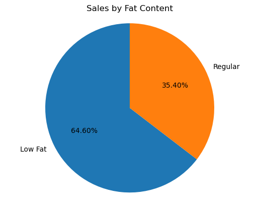

```python
sales_by_fat= df.groupby('Item Fat Content')['Sales'].sum()


plt.pie(sales_by_fat, labels= sales_by_fat.index,
                        autopct='%.2f%%',
                        startangle=90)
plt.title('Sales by Fat Content')
plt.axis('equal')
plt.show()
```

##### At an overall level, Low Fat items for 64.60% of sales, while Regular items for only 35.40%

#### **5.2 Total sales by Item Type**

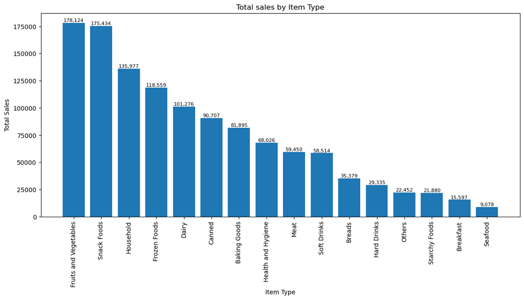

```python
sales_by_type=df.groupby('Item Type')['Sales'].sum().sort_values(ascending=False)

plt.figure(figsize=(14,6))
bars=plt.bar(sales_by_type.index,sales_by_type.values)

plt.xticks(rotation=90)
plt.xlabel('Item Type')
plt.ylabel('Total Sales')
plt.title('Total sales by Item Type')

for bar in bars:
    plt.text(bar.get_x()+bar.get_width()/2,bar.get_height(),
    f'{bar.get_height():,.0f}', ha='center', va='bottom', fontsize=8)
```

The graph above presents the total sales by Item Type, showing the corresponding dollar amounts sold. Fruits and Vegetables lead in total sales, closely followed by Snack Foods.

#### **5.3 Fat Content by Outlet for Total Sales**

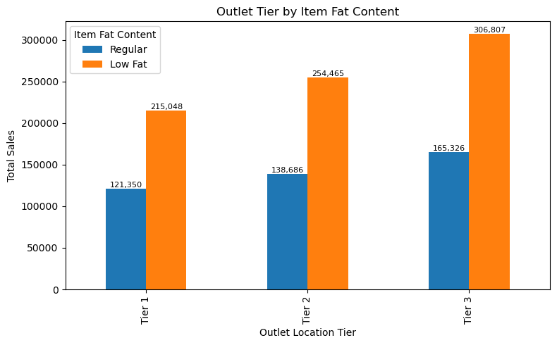

```python
grouped=df.groupby(['Outlet Location Type', 'Item Fat Content'])['Sales'].sum().unstack()
grouped= grouped[['Regular','Low Fat']]

ax=grouped.plot(kind='bar', figsize=(8,5), title=('Outlet Tier by Item Fat Content'))
plt.xlabel('Outlet Location Tier')

plt.ylabel('Total Sales')
plt.legend(title='Item Fat Content')
plt.tight_layout()


for container in ax.containers:
    for bar in container:
        height = bar.get_height()
        ax.text(bar.get_x() + bar.get_width()/2, height,
                f'{height:,.0f}', ha='center', va='bottom', fontsize=8)

plt.show()
```

This graph presents total sales by item fat content across the three outlet tiers of the company. 'Low Fat' items lead sales in all three tiers.

#### **5.4 Total Sales by Outlet Establishment**

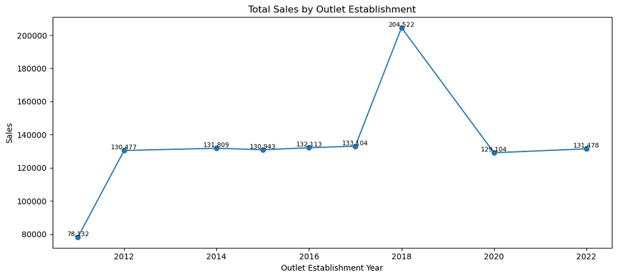

```python
sales_by_year=df.groupby(['Outlet Establishment Year'])['Sales'].sum().sort_index()
plt.figure(figsize=(11,5))
plt.plot(sales_by_year.index, sales_by_year.values,marker='o',linestyle='-')

plt.xlabel('Outlet Establishment Year')
plt.ylabel('Sales')
plt.title('Total Sales by Outlet Establishment')

for x, y in zip(sales_by_year.index,sales_by_year.values):
    plt.text(x,y,f'{y:,.0f}', ha='center', va='bottom', fontsize=8)


plt.tight_layout()
plt.show()
```

This graph represents the total sales for each outlet establishment year, along with their respective values.

Year 2012 = $130477.

Year 2014 = $131809.

Year 2015 = $130943.

Year 2016 = $132113.

Year 2018 = $204522.

Year 2020 = $129104.

Year 2022 = $131478.

#### **5.5 Sales by Outlet Establishment**

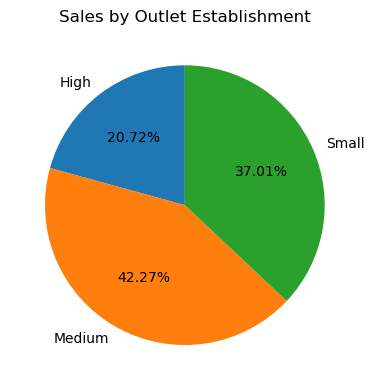

```python
sales_by_size=df.groupby('Outlet Size')['Sales'].sum()
plt.figure(figsize=(4,4))

plt.pie(sales_by_size, labels=sales_by_size.index, autopct='%1.2f%%', startangle=90)
plt.title('Sales by Outlet Establishment')

plt.tight_layout()
plt.show()
```

At an overall level, high-sized outlets account for 20.72% of total sales, small-sized outlets for 37.01%, and medium-sized outlets lead with 42.27%.

From the graph, we can observe that large outlets do not generate the highest sales, contrary to what might be expected.

#### **5.6 Sales by Outlet Location**

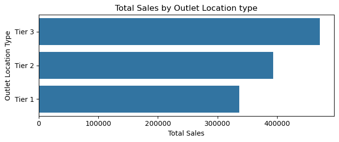

```python
sales_by_location=df.groupby('Outlet Location Type')['Sales'].sum().reset_index()
sales_by_location= sales_by_location.sort_values('Sales',ascending=False)

plt.figure(figsize=(7,3))
ax=sns.barplot(x='Sales', y='Outlet Location Type', data=sales_by_location)

plt.title('Total Sales by Outlet Location type')
plt.xlabel('Total Sales')
plt.ylabel('Outlet Location Type')

plt.tight_layout()
plt.show()
```

```python
df.groupby('Outlet Location Type')['Sales'].sum().reset_index()
```

|  | Outlet Location Type | Sales |
| --- | --- | --- |
| 0 | Tier 1 | 336397.8120 |
| 1 | Tier 2 | 393150.6476 |
| 2 | Tier 3 | 472133.0332 |

Tier 3 leads in sales with 472,133 dollars, followed by Tier 2 with 393,151 dollars, and finally Tier 1 with 336,398 dollars.